# Distribuciones Continuas

Edimer David Jaramillo

9 de mayo de 2018

# Distribución Exponencial

## Características

- De gran utilidad para modelar fenómenos relacionados con tiempos de espera.
- Múltiples aplicaciones:
  - Calcular la probabilidad de que un instrumento electrónico falle en determinado período de tiempo.
  - El tiempo necesario para que ocurra un accidente de tránsito en una ruta en una vía con probabilidad $P$.
  - El tiempo que puede transcurrir en un servicio de urgencias para que llegue el próximo paciente.
  - Teoría de colas
  - Problemas de confiabilidad
- En un proceso Poisson donde se repite sucesivamente un experimento a intervalos de tiempo iguales, el tiempo que transcurre entre dos sucesos sigue un modelo probabilístico exponencial.

Una variable aleatoria $X$ tiene distribución Exponencial si su función de densidad es:
$$f(x) = \lambda e^{-\lambda x}$$

Notación:
$$X \sim Exp(\lambda)$$

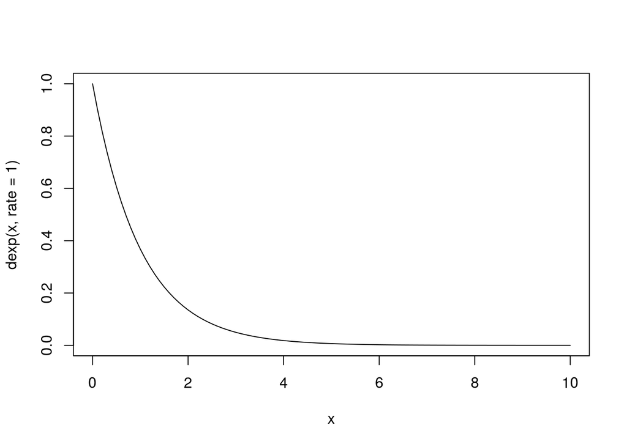

```r
curve(dexp(x, rate = 1), from = 0, to = 10)  # Representa la densidad de una exponencial con lambda igual a 1, con valores entre 0 y 10
```

## Esperanza Matemática

$$E[X]=\frac{1}{\lambda}$$

## Varianza

$$Var[X]=\frac{1}{\lambda^2}$$

## Ejemplos

### Ejemplo 1

De registros históricos se sabe que en promedio, un rayo causa la muerte a tres personas cada año en determinado país. Obtener:

- La probabilidad de que el tiempo hasta la próxima muerte sea menor a un año
- La probabilidad de que el tiempo hasta la próxima muerte sea mayor a 18 meses.

Funciones importantes:

- `rexp()`: generar números bajo la distribución Exponencial
- `pexp()`: función de densidad (probabilidades)
- `qexp()`: obtener cuantiles

```r
#P(X < 1)
pexp(q = 1, rate = 3)
```

```
## [1] 0.9502129
```

```r
#P(X > 1.5)
pexp(q = 1.5, rate = 3, lower.tail = FALSE)
```

```
## [1] 0.011109
```

```r
#P(X > 1.5)
1 - pexp(q = 1.5, rate = 3)
```

```
## [1] 0.011109
```

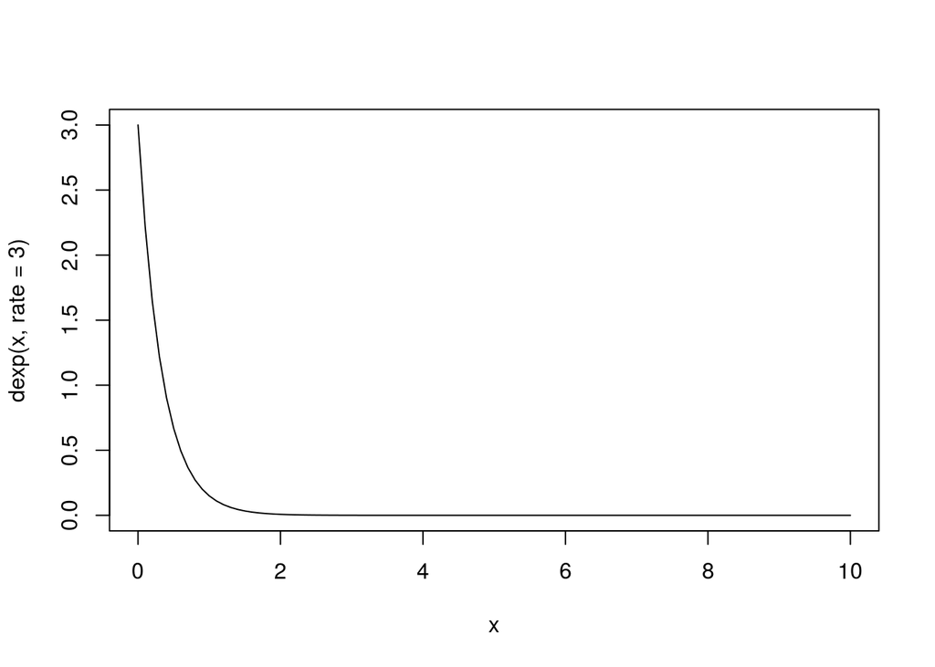

```r
curve(dexp(x, rate = 3), from = 0, to = 10)
```

```r
datos_exp <- rexp(n = 100, rate = 3)
head(datos_exp)
```

```
## [1] 0.1128320 0.0861721 0.1874912 0.2847231 0.1744140 0.4218336
```

### Ejemplo 2

En un experimento de laboratorio se utilizan 10 gramos de $X$ compuesto químico, se conoce que la duración media de un átomo de esta materia es de 140 días; obtener:

1. La probabilidad de que el compuesto desaparezca máximo a los 100 días.
2. La probabilidad de que el compuesto desaparezca en mínimo 50 días
3. Los días que transcurren hasta que haya desaparecido el 90% de este material.

```r
# Respuesta A
pexp(q = 100, rate = 1/140)
```

```
## [1] 0.5104583
```

```r
#Respuesta B
pexp(q = 50, rate = 1/140, lower.tail = FALSE)
```

```
## [1] 0.6996725
```

```r
#Respuesta C (en días)
qexp(p = 0.90, rate = 1/140)
```

```
## [1] 322.3619
```

```r
#Probabilidad de desaparición en máximo 322 días
pexp(q = 322, rate = 1/140)
```

```
## [1] 0.8997412
```

## Ejercicio

- Se ha comprobado que el tiempo de vida útil de cierto tipo de marcapasos sigue una distribución exponencial con media de 16 años. Obtener:
  - La probabilidad de que a un paciente al que se le ha implantado el marcasos, deba reemplazarlo por otro antes de 20 años.
  - La probabilidad de que haya que cambiar el marcapasos máximo a los 25 años en un paciente que tiene el implante hace 5 años.
  - El tiempo transcurrido hasta que exista una probabilidad máximo del 80% de reemplazarlo.

```r
Respuesta_1.1
```

```
## [1] 0.7134952
```

```r
Respuesta_1.2
```

```
## [1] 0.5220042
```

```r
Respuesta_1.3
```

```
## [1] 25.75101
```

# Distribución Normal

## Características

- De gran utilidad para múltiples fenómenos de la vida real
  - Agronómicos
  - Biológicos
  - Químicos
  - Físicos
  - Antropológicos
- Centralizada en la media
- La curva tiene su máximo absoluto en $\mu$
- La curva es simétrica a través de $\mu$
- Se aproxima al eje horizontal sin tocarlo (curva asintótica)
- El área total bajo la curva es 1

Una variable aleatoria $X$ tiene distribución Normal si su función de densidad es:
$$f(x) = \frac{1}{\sqrt{2 \pi \sigma}}e^{-\frac{(x - \mu)^2}{2 \sigma^2}};\ con\ \sigma > 0$$

Notación:
$$X \sim N(\mu,\ \sigma^2)$$

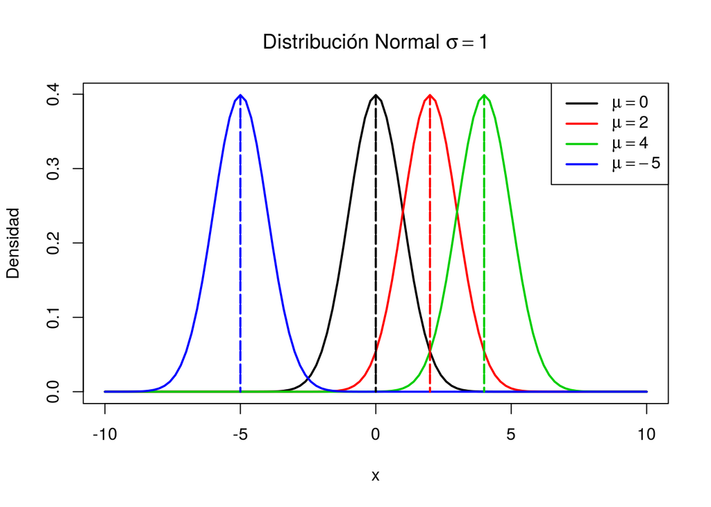

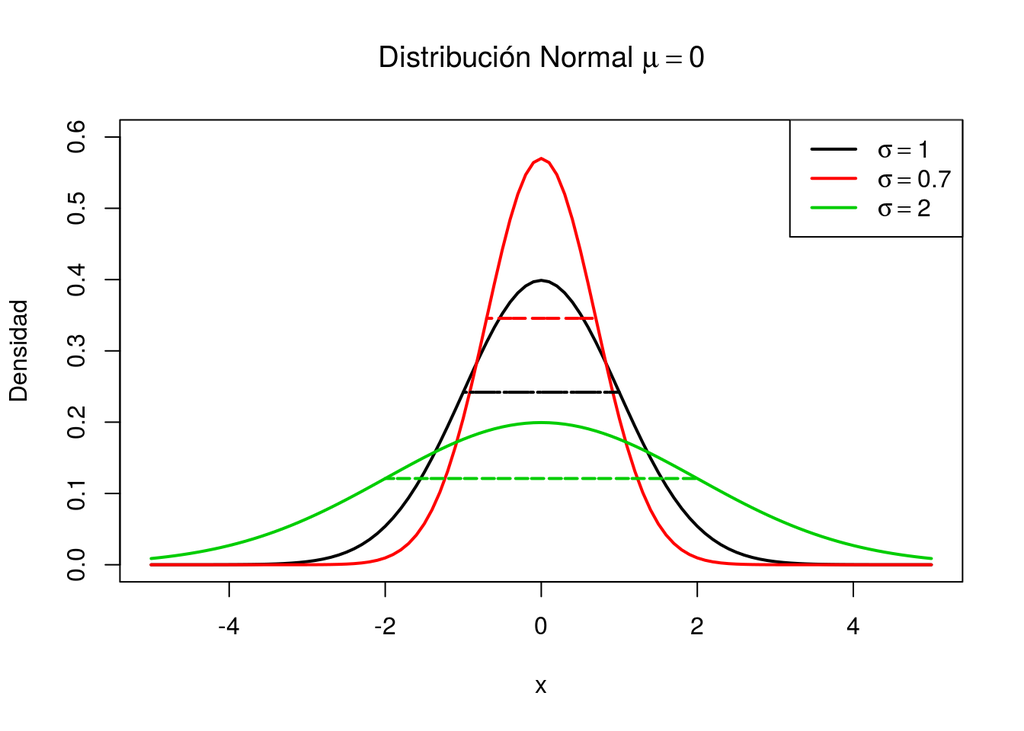

### Utilidades

- Obtener la probabilidad de que una variable aleatoria $X$ tome valores menores a un valor determinado.

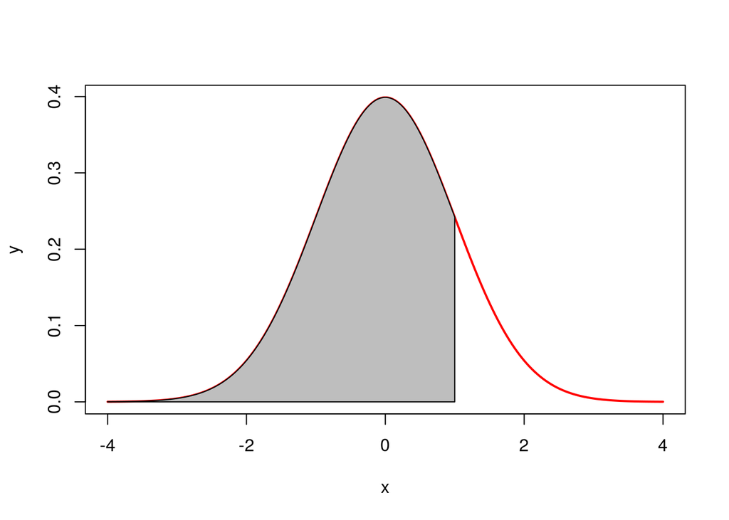

- Obtener la probabilidad de que una variable aleatoria $X$ tome valores mayores a un valor determinado.

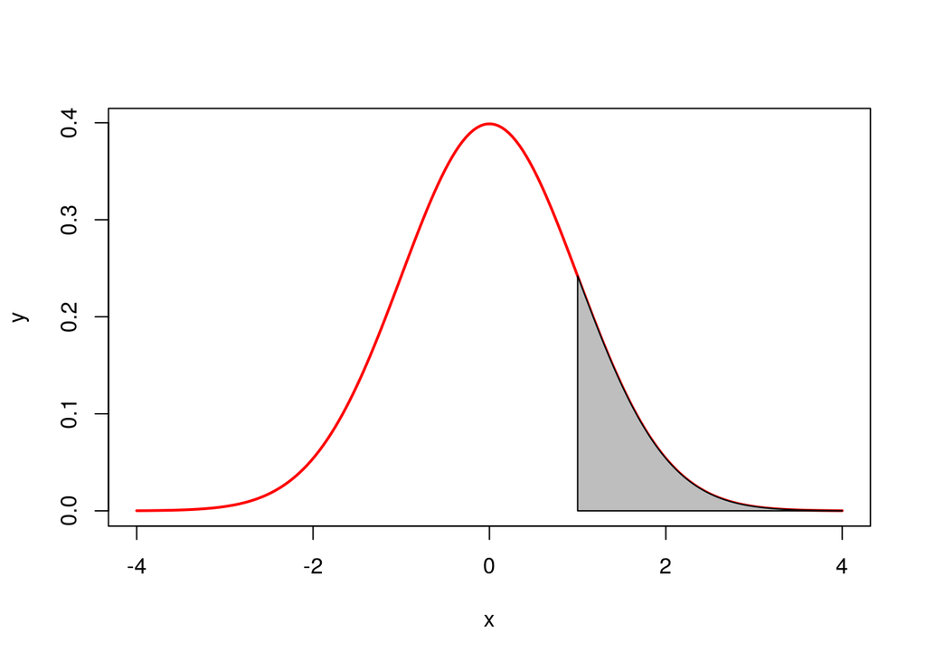

- Obtener la probabilidad de que una variable aleatoria $X$ tome valores entre dos valores determinados.

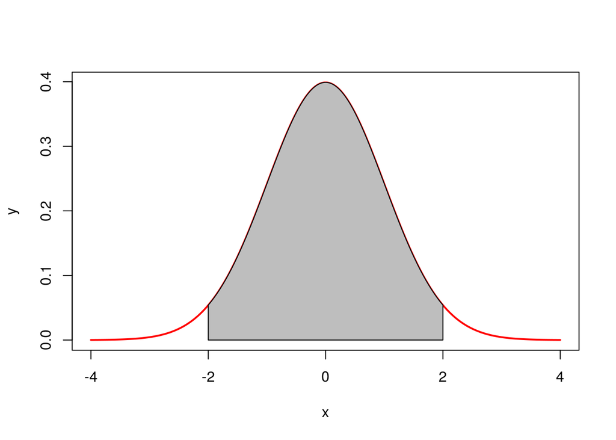

## Esperanza Matemática

$$E[X]=\mu$$

## Varianza

$$Var[X]=\sigma^2$$

## Distribución Normal Estándar

Notación:
$$Z \sim N(\mu=0,\ \sigma^2=1)$$

### Estandarización

$$z = \frac{X - \mu}{\sigma}$$

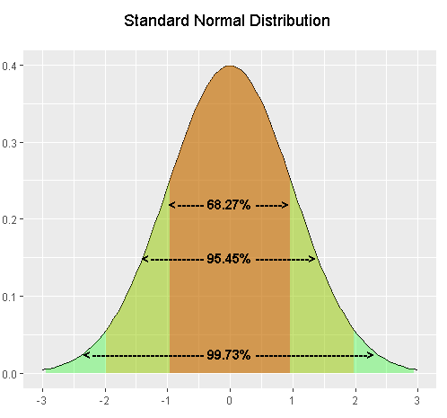

[Tabla Z](https://bioestadistica.github.io/Temas/Z.pdf)

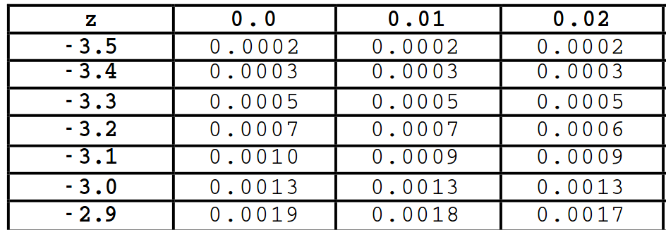

### Ejemplo

Si $X$ sigue una distribución normal con media igual a 10 y sigma igual a 2. ¿Cuál es la probabilidad de que la medida de la variable aleatoria $X$ esté entre 9 y 11?

**Solución:**

1. **Estandarizar**

$$P(9 < X < 11) = P(\frac{9-10}{2} < \frac{x-10}{2} < \frac{11-10}{2}) \\
P(-0.5 < z < 0.5 \\
P(z < 0.5) - P(z < -0.5) = 0.38292$$

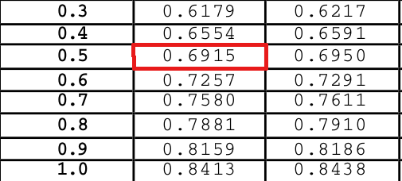

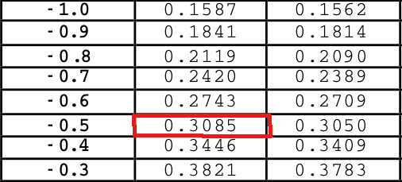

$$0.6915 - 0.3085 = 0.383$$

2. **Con R**

Funciones importantes:

```r
pz_menor0.5 <- pnorm(q = 0.5)
pz_menor_menos0.5 <- pnorm(q = -0.5)
pz_menor0.5 - pz_menor_menos0.5
```

```
## [1] 0.3829249
```

## Ejemplos

1. Asuma que la variable aleatoria $Z$ sigue una distribución normal estándar, obtener:
1. $P(Z \leq 1.37)$
2. $P(Z \leq -0.86)$
3. $P(-1.25 \leq Z \leq 0.37)$
4. $P(Z > -1.23)$

**Solución literal a ($P(Z \leq 1.37)$):**

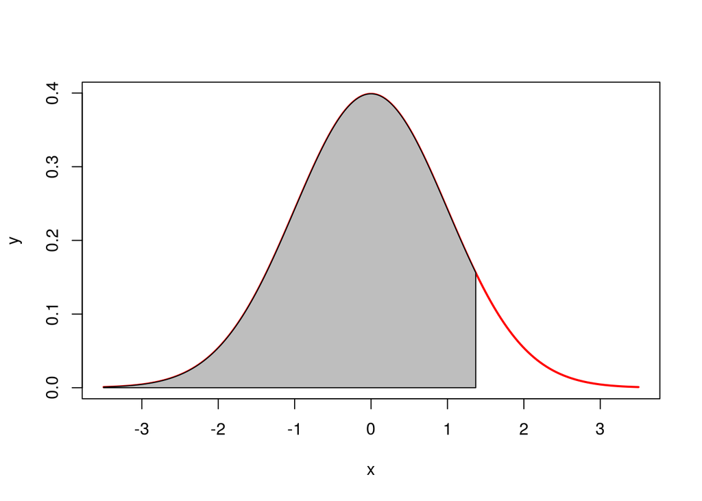

```r
x <- seq(-3.5, 3.5, length = 200)
y <- dnorm(x)
plot(x, y, type = "l", lwd = 2, col = "red")
x <- seq(-3.5, 1.37, length = 200)
y <- dnorm(x)
polygon(c(-3.5, x, 1.37), c(0, y, 0), col = "gray")
```

- **Con tabla Z**

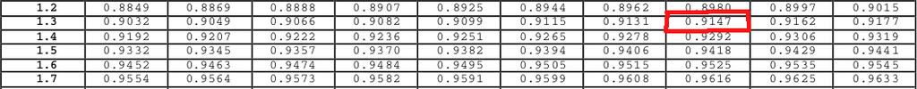

- **Con R**

```r
#P(Z <= 1.37)
pnorm(q = 1.37, mean = 0, sd = 1)
```

```
## [1] 0.9146565
```

**Solución literal b ($P(Z \leq -0.86)$):**

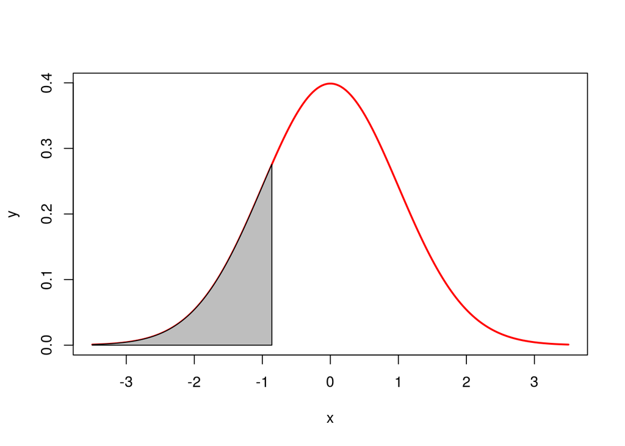

```r
x <- seq(-3.5, 3.5, length = 200)
y <- dnorm(x)
plot(x, y, type = "l", lwd = 2, col = "red")
x <- seq(-3.5, -0.86, length = 200)
y <- dnorm(x)
polygon(c(-3.5, x, -0.86), c(0, y, 0), col = "gray")
```

- **Con tabla Z**

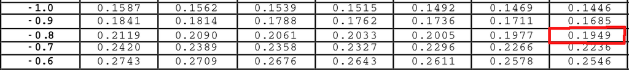

- **Con R**

```r
#P(Z <= -0.86)
pnorm(q = -0.86, mean = 0, sd = 1)
```

```
## [1] 0.1948945
```

**Solución literal c ($P(-1.25 \leq Z \leq 0.37$):**

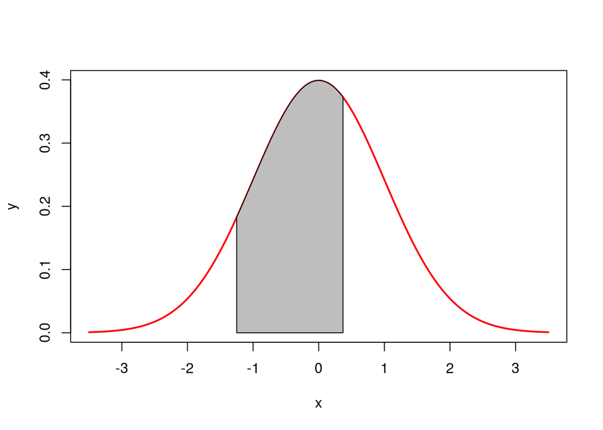

```r
x <- seq(-3.5, 3.5, length = 200)
y <- dnorm(x)
plot(x, y, type = "l", lwd = 2, col = "red")
x <- seq(-1.25, 0.37, length = 200)
y <- dnorm(x)
polygon(c(-1.25, x, 0.37), c(0, y, 0), col = "gray")
```

- **Con tabla Z**

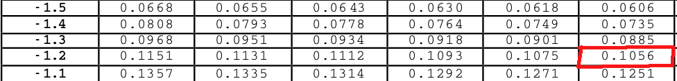

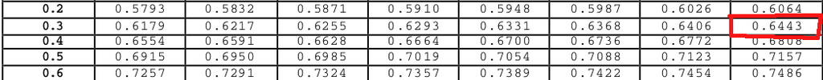

$$0.6443 - 0.1056 = 0.5387$$

- **Con R**

```r
#P(-1.25 <= Z <= 0.37)
p1.25 <- pnorm(q = -1.25, mean = 0, sd = 1)
p0.37 <- pnorm(q = 0.37, mean = 0, sd = 1)
(resta <-  p0.37 - p1.25)
```

```
## [1] 0.538659
```

**Solución literal d ($P(Z \geq -1.23)$):**

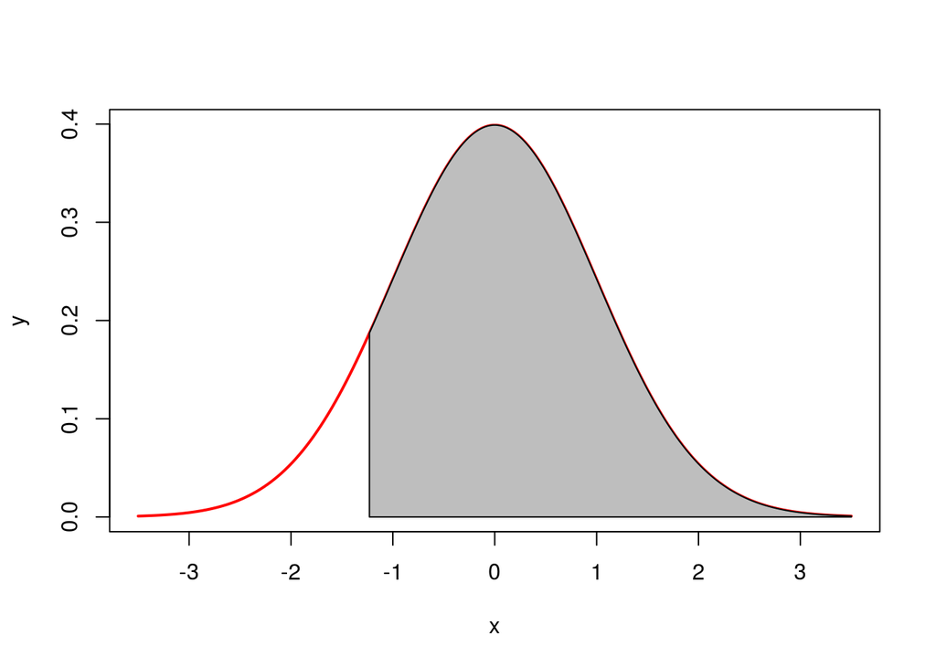

```r
x <- seq(-3.5, 3.5, length = 200)
y <- dnorm(x)
plot(x, y, type = "l", lwd = 2, col = "red")
x <- seq(-1.23, 3.5, length = 200)
y <- dnorm(x)
polygon(c(-1.23, x, 3.5), c(0, y, 0), col = "gray")
```

- **Con tabla Z**

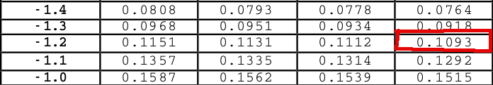

$$1 - 0.1093 = 0.8907$$

- **Con R**

```r
#P(X > -1.23)
1 - pnorm(q = -1.23)
```

```
## [1] 0.8906514
```

```r
#Editanto el parámetro lower.tail
pnorm(q = -1.23, lower.tail = FALSE)
```

```
## [1] 0.8906514
```

2. El caudal de un canal de riego medido en $m^3/seg$ es una variable aleatoria con distribución aproximadamente normal con media $3m^3/seg$ y desviación estándar de $0.8m^3/seg$. Con esta información, obtener la probabilidad de los siguientes eventos:
- **Evento A:** que el caudal en un momento dado sea máximo de $2.4m^3/seg$
- **Evento B:** que el caudal en un momento dado esté entre $2.8\ y\ 3.4m^3/seg$
- **Evento C:** que el caudal en un momento dado sea al menos de $2m^3/seg$

**Solución con R:**

- **Evento A:**

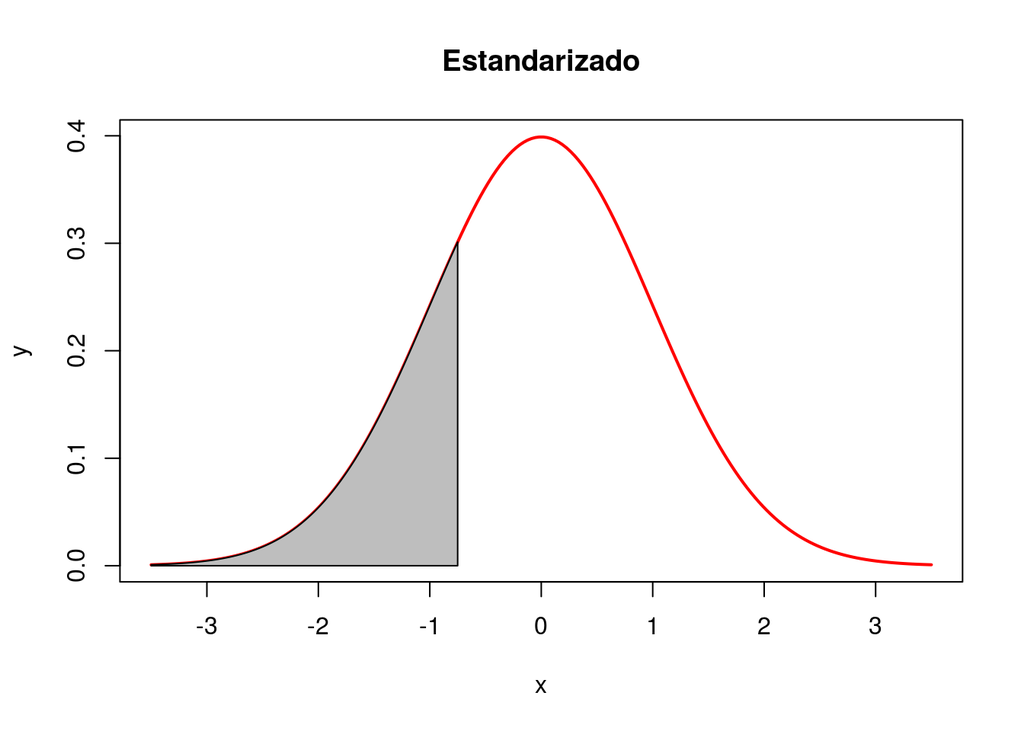

```r
x <- seq(-3.5, 3.5, length = 200)
y <- dnorm(x)
plot(x, y, type = "l", lwd = 2, col = "red", main = "Estandarizado")
x <- seq(-3.5, -0.75, length = 200)
y <- dnorm(x)
polygon(c(-3.5, x, -0.75), c(0, y, 0), col = "gray")
```

```r
#Evento A
#P(X <= 2.4) - Estandarizando
(diametro_estandarizada_2.4 <- (2.4 - 3)/0.8)
```

```
## [1] -0.75
```

```r
pnorm(q = diametro_estandarizada_2.4, mean = 0, sd = 1)
```

```
## [1] 0.2266274
```

```r
#Evento A
# P(X <= 2.4) - Sin estandarizar
pnorm(q = 2.4, mean = 3, sd = 0.8)
```

```
## [1] 0.2266274
```

- **Evento B:**

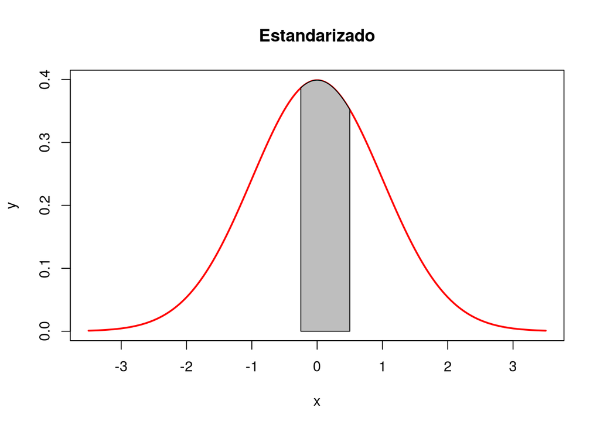

```r
x <- seq(-3.5, 3.5, length = 200)
y <- dnorm(x)
plot(x, y, type = "l", lwd = 2, col = "red", main = "Estandarizado")
x <- seq(-0.25, 0.5, length = 200)
y <- dnorm(x)
polygon(c(-0.25, x, 0.5), c(0, y, 0), col = "gray")
```

```r
#Evento B
#P(2.8 <= X <= 3.4) - Estandarizando
(diametro_estandarizada_2.8 <- (2.8 - 3)/0.8)
```

```
## [1] -0.25
```

```r
(diametro_estandarizada_3.4 <- (3.4 - 3)/0.8)
```

```
## [1] 0.5
```

```r
pnorm(q = diametro_estandarizada_3.4) - pnorm(q = diametro_estandarizada_2.8)
```

```
## [1] 0.2901688
```

```r
#Evento B
# P(2.8 <= X <= 3.4) - Sin estandarizar
pnorm(q = 3.4, mean = 3, sd = 0.8) - pnorm(q = 2.8, mean = 3, sd = 0.8)
```

```
## [1] 0.2901688
```

- **Evento C:**

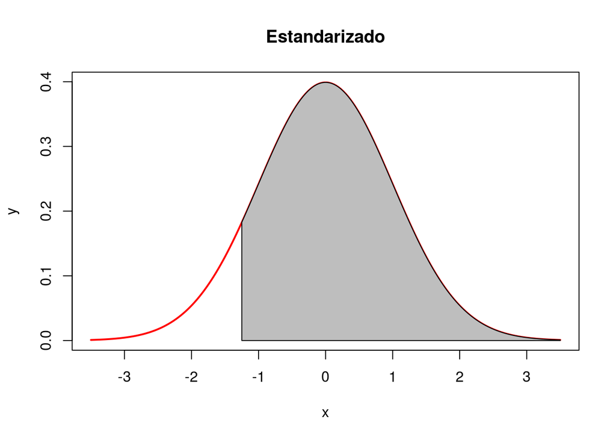

```r
x <- seq(-3.5, 3.5, length = 200)
y <- dnorm(x)
plot(x, y, type = "l", lwd = 2, col = "red", main = "Estandarizado")
x <- seq(-1.25, 3.5, length = 200)
y <- dnorm(x)
polygon(c(-1.25, x, 3.5), c(0, y, 0), col = "gray")
```

```r
#Evento C
#P(X >= 2) - Estandarizando
(diametro_estandarizada_2 <- (2 - 3)/0.8)
```

```
## [1] -1.25
```

```r
1 - pnorm(q = diametro_estandarizada_2)
```

```
## [1] 0.8943502
```

```r
#Evento C
#P(X >= 2) - Sin estandarizar
pnorm(q = 2, mean = 3, sd = 0.8, lower.tail = FALSE)
```

```
## [1] 0.8943502
```

## Ejercicios

1. Si $X$ es una variable aleatoria distribuida normalmente con $\mu = 10$ y $\sigma^2 = 4$
   1. ¿Cuál es la probabilidad de que $X$ tome valores menores a 9?
   2. ¿Cuál es la probabilidad de que $X$ tome valores entre 9 y 11?

```r
Respuesta_1A
```

```
## [1] 0.3085375
```

```r
Respuesta_1B
```

```
## [1] 0.3829249
```

2. Si la variable espesor de un sedimento en un sustrato de suelo es una variable aleatoria distribuida normalmente con $\mu = 15\ micrones$ y $\sigma = 3\ micrones$
   1. ¿Cuál es la probabilidad de que el espesor tome valores menores a 12.75?
   2. ¿Cuál es el cuantil 0.75 de la distribución?
   3. ¿Cómo se interpreta el valor del literal b?

```r
Respuesta_2A
```

```
## [1] 0.2266274
```

```r
Respuesta_2B
```

```
## [1] 17.02347
```

3. El día de floración de una hortaliza (en escala de 1 -365 días) se puede modelar con una distribución normal centrada en el 18 de agosto (día 230) y con desviación estándar de 10 días. Si desde la fecha de la floración hasta la cosecha hay un lapso de 25 días, obtener:
   1. La proporción de la cosecha que se habrá generado para el 16 de septiembre (día 259).
   2. Si se considera **primicia** a los frutos obtenidos antes del 1 de septiembre (día 244), ¿qué proporción de la cosecha se espera sea primicia?
   3. Si se considera **tardío** a los frutos obtenidos después del 20 de septiembre (día 263), ¿cuál es la proporción esperada de frutos tardíos?

```r
Respuesta_A
```

```
## [1] 0.6554217
```

```r
Respuesta_B
```

```
## [1] 0.1356661
```

```r
Respuesta_C
```

```
## [1] 0.2118554
```

# Distribución Chi Cudrado

## Características

- Llamada también *ji cuadrada (o)* o distribución de Pearson
- Aplicación considerable en la teoría y metodología estadística
- Componente importante de las pruebas de hipótesis e inferencia estadística
- Relacionada con las distribuciones T de Student y F de Snedecor

Una variable aleatoria $X$ tiene distribución chi cuadrado si su función de densidad es:
$$\frac{1}{2^{\frac{k}{2}}\Gamma(k/2)}x^{(k/2)-1}e^{-x/2}$$

Notación:
$$X \sim \chi^2(k)$$

[Tabla $\chi^2$](https://bioestadistica.github.io/Temas/Jicuadrado.pdf)

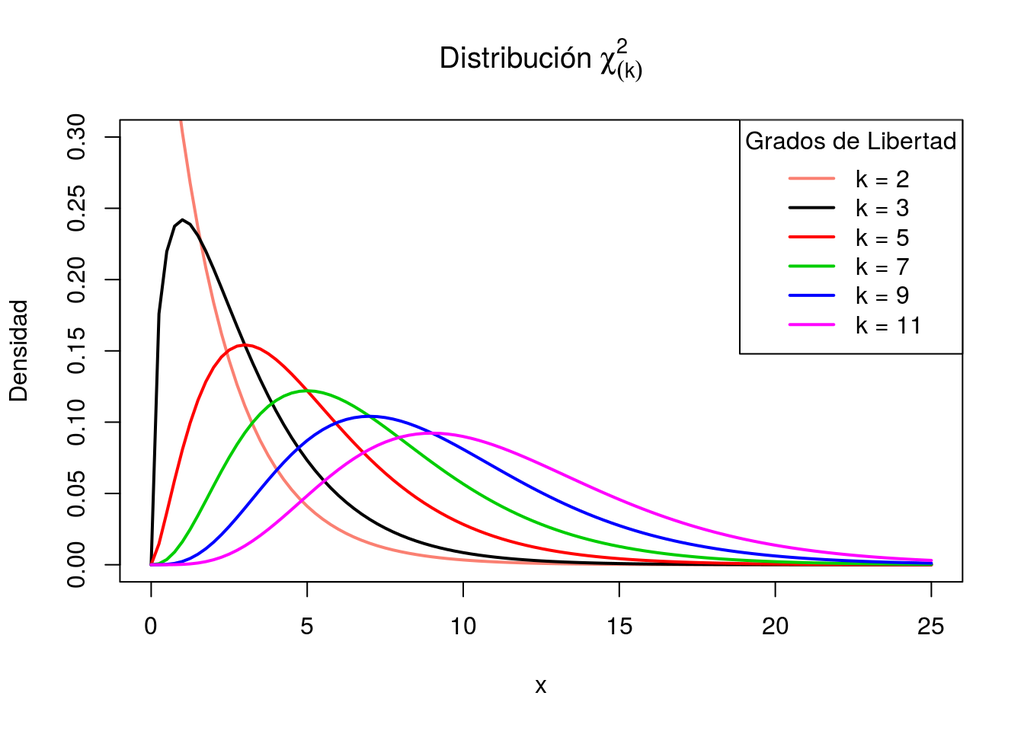

## Esperanza Matemática

$$E[X] = k$$

## Varianza

$$Var[X] = 2k$$